# AnjuPandey_FinalReport

```
Found 128 images belonging to 4 classes.
```

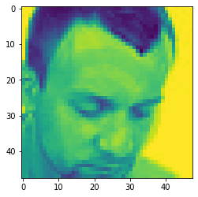

```
Image- 1
sad ------predicted as-----> happy
```

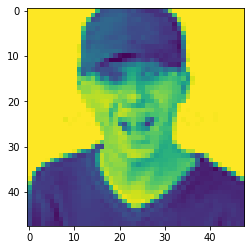

```
Image- 2
surprise ------predicted as-----> sad
```

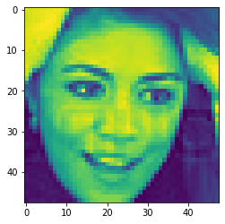

```
Image- 3
surprise ------predicted as-----> happy
```

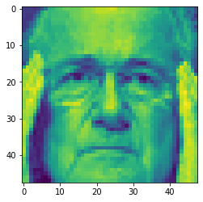

```
Image- 4
surprise ------predicted as-----> neutral
```

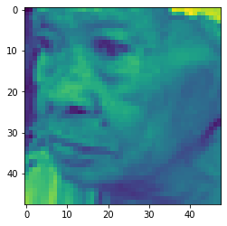

```
Image- 5
neutral ------predicted as-----> sad
```

[figure not shown]

```
Image- 6
neutral ------predicted as-----> sad
```

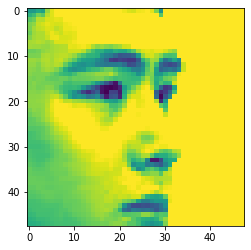

```
Image- 7
sad ------predicted as-----> surprise
```

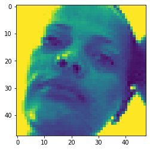

```
Image- 8
sad ------predicted as-----> happy
```

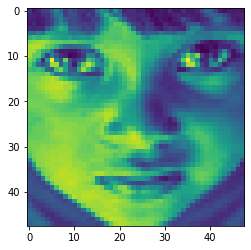

```
Image- 9
sad ------predicted as-----> happy
```

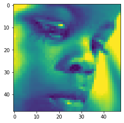

```
Image- 10
neutral ------predicted as-----> sad
```

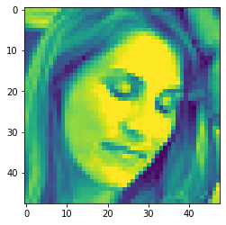

```
Image- 11
sad ------predicted as-----> happy
```

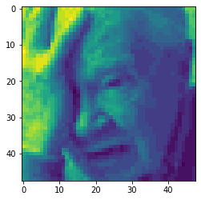

```
Image- 12
sad ------predicted as-----> neutral
```

[15 more figures not shown]

```
Image- 27
happy ------predicted as-----> neutral
```

```python
# Plot the confusion matrix and generate a classification report for the model
%matplotlib inline
from PIL import Image
from keras_preprocessing.image import img_to_array,array_to_img
from sklearn.metrics import classification_report
from sklearn.metrics import confusion_matrix

test_set = datagen_test.flow_from_directory(folder_path + "test",
            target_size = (img_size,img_size),
            color_mode = 'grayscale',
            batch_size = 128,
            class_mode = 'categorical',
            classes = ['happy', 'sad', 'neutral', 'surprise'],
            shuffle = True)

def expression(e):
  result=''
  if e==0 :
    result= "happy"
  elif e==1 :
    result= "sad"
  elif e==2 :
    result= "neutral"
  elif e==3 :
    result= "surprise"
  return result

test_images, test_labels = next(test_set)

pred = mdl.predict(test_images)
pred = np.argmax(pred, axis = 1)
y_true = np.argmax(test_labels, axis = 1)
imagenum=0
for i in range(len(pred)):
  if pred[i]!=y_true[i]:
    plt.imshow(array_to_img(test_images[i]))
    plt.show()
    imagenum=imagenum+1
    print('Image-',imagenum)
    print(expression(y_true[i]),'------predicted as----->',expression(pred[i]))
```

**Inference:**  
Above result is giving some insight of model’s performance. There are many expressions which are confusing even for human to differentiate. For example, Image-4 is predicted as neutral but actual result is ‘surprise’.  
However, there are many images where model is completely failing to classify. For example- Image-1 is predicted as ‘happy’ though its clearly ‘sad’ face. Image-2 is ‘surprise’ but predicted as ‘sad’.

Lets plot some images of correct predictions and check if model is learning anything.

```
---------- Correct Predictions ----------
```

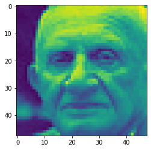

```
Image- 1
neutral ------predicted as-----> neutral
```

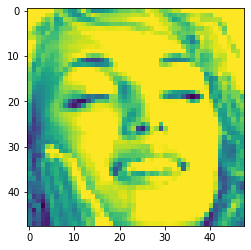

```
Image- 2
happy ------predicted as-----> happy
```

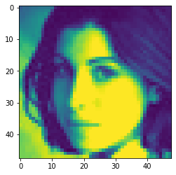

```
Image- 3
neutral ------predicted as-----> neutral
```

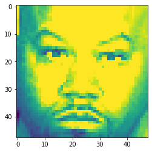

```
Image- 4
neutral ------predicted as-----> neutral
```

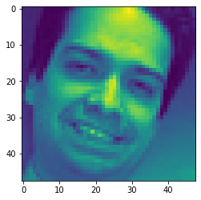

```
Image- 5
happy ------predicted as-----> happy
```

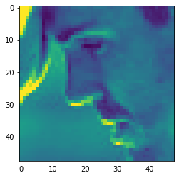

```
Image- 6
sad ------predicted as-----> sad
```

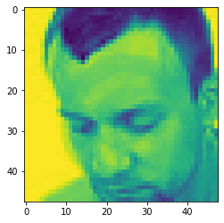

```
Image- 7
sad ------predicted as-----> sad
```

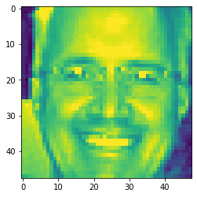

```
Image- 8
happy ------predicted as-----> happy
```

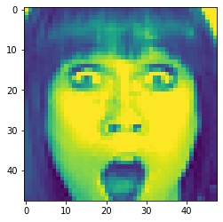

```
Image- 9
surprise ------predicted as-----> surprise
```

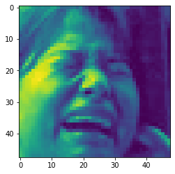

```
Image- 10
sad ------predicted as-----> sad
```

```python
imagenum=0
cntr=0
print("-"*10,'Correct Predictions','-'*10)
for i in range(len(pred)):
  if pred[i]==y_true[i] and cntr<10:
    plt.imshow(array_to_img(test_images[i]))
    plt.show()
    imagenum=imagenum+1
    print('Image-',imagenum)
    print(expression(y_true[i]),'------predicted as----->',expression(pred[i]))
    cntr=cntr+1
```

**Conclusion:**  
Model achieved approx. 78% of accuracy, it is predicting many images correctly however some images are clearly misclassified. So, model has certainly learned some parameters but not enough to be implemented in real life scenario.  
**Recommendation:**  
Model is not recommended for practical use. More study and investigation need to be done for better architecture.